# Sample size calculation for Hui-Walter models

Matt Denwood

2023-05-13

## Basic principle

There is no “standard” sample size calculation for Hui-Walter type models, so we must do it the brute force way: by simulating data, analysing the data, and looking at the width of the confidence intervals. Fortunately Hui-Walter models run relatively quickly, but it is still a reasonably big computational exercise.

### Packages

The programming style is heavily functional so we have a strong tidyverse dependency (#sorrynotsorry). We also need runjags and pbapply.

If necessary:

```r
install.packages(c("tidyverse","runjags","pbapply"))
```

Load packages:

```r
library("tidyverse")
library("runjags")
library("pbapply")
library("coda")
library("parallel")
theme_set(theme_light())
```

### Data simulation

This function simulates data with given input parameters and returns it as a list:

```r
datafun <- function(parameters, iterations = 50){

  ## Cursory argument checks:
  countries <- 4L
  stopifnot(is.data.frame(parameters), nrow(parameters)==1L, all(c("Scenario", "N_uk", "N_nl", "N_fr", "N_se","prev_uk", "prev_nl", "prev_fr", "prev_se", "se_1", "sp_1", "se_2", "sp_2") %in% names(parameters)))
  stopifnot(all(parameters |> mutate(N_tot = N_uk+N_nl+N_fr+N_se) |> pull(N_tot) == 500L))

  ## Simulate data:
  tibble(
    Country = factor(c("UK", "NL", "FR", "SE"), levels=c("UK", "NL", "FR", "SE")),
    Prevalence = parameters[c("prev_uk", "prev_nl", "prev_fr", "prev_se")] |> as.numeric(),
    N = parameters[c("N_uk", "N_nl", "N_fr", "N_se")] |> as.numeric()
  ) |>
    group_split(Country) |>
    lapply(function(x){
      c(
        x$Prevalence * (1-parameters$se_1)*(1-parameters$se_2),
        x$Prevalence * (parameters$se_1)*(1-parameters$se_2),
        x$Prevalence * (1-parameters$se_1)*(parameters$se_2),
        x$Prevalence * (parameters$se_1)*(parameters$se_2)
      ) + c(
        (1-x$Prevalence) * (parameters$sp_1)*(parameters$sp_2),
        (1-x$Prevalence) * (1-parameters$sp_1)*(parameters$sp_2),
        (1-x$Prevalence) * (parameters$sp_1)*(1-parameters$sp_2),
        (1-x$Prevalence) * (1-parameters$sp_1)*(1-parameters$sp_2)
      ) ->
        probs
      stopifnot(all.equal(1.0, sum(probs)))

      rmultinom(iterations, x$N, probs)
    }) ->
    simdata

  ## Generate initial values based on true values:
  # [Note we use the same values for 2 chains, which is normally
  # not recommended, but OK for analysing simulated data]
  list(
    se = parameters[c("se_1", "se_2")] |> as.numeric(),
    sp = parameters[c("sp_1", "sp_2")] |> as.numeric(),
    prev = parameters[c("prev_uk", "prev_nl", "prev_fr", "prev_se")] |> as.numeric()
  ) |>
    replicate(n=2L, expr=_, simplify=FALSE) ->
    inits

  ## Transform to a list per iteration and return:
  1:iterations |>
    lapply(function(x){
      1:countries |>
        sapply(function(y) simdata[[y]][,x] |> as.numeric()) ->
        dd
      list(Parameters=parameters,
           Iteration=x,
           Data=list(Tally=dd,
                     N=parameters[c("N_uk", "N_nl", "N_fr", "N_se")] |> as.numeric(),
                     Populations=4L),
           Inits=inits
      )
    })
}
```

We can use the function with different sets of parameters as well, for example 3 different scenarios each giving Sweden a different proportion of the total:

```r
tibble(
  Scenario = 1:3,
  N_uk = c(50,125,150),
  N_nl = c(50,125,150),
  N_fr = c(50,125,150),
  N_se = c(350,125,50)
) |>
  cross_join(
    tibble(prev_uk=0.5, prev_nl=0.4, prev_fr=0.7, prev_se=0, se_1=0.9, sp_1=0.99, se_2=0.95, sp_2=0.98)
  ) |>
  group_split(Scenario) |>
  lapply(datafun, iterations=50) |>
  flatten() ->
  datasets

length(datasets)
```

```
## [1] 150
```

### Model function

This function analyses the data, and returns the estimates of the diagnostic test parameters (i.e. it does the underlying work for the sample size calculation):

```r
modelfun <- function(datasets, samples=10000, se_prior = "dbeta(1,1)T(0.5,)", sp_prior = "dbeta(1,1)T(0.5,)", sweden_prior = "dbeta(1,1)", cl=NULL){

  stopifnot(all(c("Parameters","Data","Inits") %in% names(datasets[[1L]])))

  ## Build the model:
  mod <- str_c("model{
    for(p in 1:Populations){
        Tally[1:4,p] ~ dmulti(prob[1:4,p], N[p])
        prob[1,p] <- prev[p] * ((1-se[1])*(1-se[2]))  +  (1-prev[p]) * (sp[1])*(sp[2])
        prob[2,p] <- prev[p] * (se[1]*(1-se[2]))  +  (1-prev[p]) * (1-sp[1])*sp[2]
        prob[3,p] <- prev[p] * ((1-se[1])*(se[2]))  +  (1-prev[p]) * (sp[1])*(1-sp[2])
        prob[4,p] <- prev[p] * (se[1]*se[2])  +  (1-prev[p]) * (1-sp[1])*(1-sp[2])
    }
    for(p in 1:(Populations-1)){
    prev[p] ~ dbeta(1,1)
    }
    prev[Populations] ~ ", sweden_prior, "

    se[1] ~ ", se_prior, "
    se[2] ~ ", se_prior, "
    sp[1] ~ ", sp_prior, "
    sp[2] ~ ", sp_prior, "
}")

  ## In case we are using a PSOCK cluster:
  runjags.options(silent.jags=TRUE, silent.runjags=TRUE)
  if(!is.null(cl) && !is.numeric(cl)){
    clusterEvalQ(cl, {
      library("tidyverse")
      library("runjags")
      library("coda")
      runjags.options(silent.jags=TRUE, silent.runjags=TRUE)
    })
  }

  ## Internal slave function:
  slavefun <- function(x, mod){

    ss <- try({
      res <- run.jags(mod, monitor=c("se","sp"), data=x[["Data"]], inits=x[["Inits"]], method="rjags", summarise=FALSE)
      cres <- res |> combine.mcmc()
      hpd <- HPDinterval(cres)

      x[["Parameters"]] |>
        select(-se_1, -sp_1, -se_2, -sp_2) |>
        bind_cols(
          tibble(
            Iteration = x[["Iteration"]],
            Parameter = c("se_1","se_2","sp_1","sp_2"),
            Target = c(x[["Inits"]][[1]][["se"]], x[["Inits"]][[1]][["sp"]]),
            Median = apply(cres, 2, median),
            LCI = hpd[,1],
            UCI = hpd[,2],
            SSeff = effectiveSize(res |> as.mcmc.list()),
            PSRF = gelman.diag(res |> as.mcmc.list(), multivariate=FALSE, autoburnin=FALSE)[[1]][,1],
            Status = "OK"
          )
        ) ->
        rv
    }, silent=TRUE)

    if(inherits(ss, "try-error")){
      x[["Parameters"]] |>
        select(-se_1, -sp_1, -se_2, -sp_2) |>
        bind_cols(
          tibble(
            Iteration = x[["Iteration"]],
            Parameter = c("se_1","se_2","sp_1","sp_2"),
            Target = c(x[["Inits"]][[1]][["se"]], x[["Inits"]][[1]][["sp"]]),
            Median = NA_real_,
            LCI = NA_real_,
            UCI = NA_real_,
            SSeff = NA_real_,
            PSRF = NA_real_,
            Status = as.character(ss)
          )
        ) ->
        rv
    }

    return(rv)
  }

  datasets |>
    pblapply(slavefun, mod=mod, cl=cl) |>
    bind_rows()

}
```

We can run the model function using our example datasets as input:

```r
datasets |>
  modelfun(cl=10L, sweden_prior="dbeta(1,100)") ->
  results
```

It takes around 10 seconds to analyse these 150 datasets on my machine using 10 cores in parallel, so although this is computationally intensive it is quite feasible as long as we keep the number of scenarios manageable.

Note: on Windows I think you have to create the cluster manually (as Fork clusters are not available):

```r
cl <- makePSOCKcluster(10L)
datasets |>
  modelfun(cl=cl) ->
  results
stopCluster(cl)
```

### Summarising results

The first thing to notice from the results is that we don’t seem to have to worry too much about convergence or sample size - so we can just stick with the default 10000 samples (and 5000 burnin):

```r
results |>
  select(SSeff, PSRF) |>
  summary()
```

```
##      SSeff            PSRF
##  Min.   : 1987   Min.   :1.000
##  1st Qu.: 5007   1st Qu.:1.000
##  Median : 6682   Median :1.000
##  Mean   : 6827   Mean   :1.000
##  3rd Qu.: 8838   3rd Qu.:1.001
##  Max.   :11114   Max.   :1.009
```

In order to get anywhere, we need to summarise results by scenario. The 3 things I am looking at are:

1. Bias of the median relative to the true value
2. The mean width of the 95% CI
3. The mean width of the 95% CI relative to one minus the true value (so that e.g. a 1 percentage point width for 99% specificity is more important than a 1 percentage point width for 95% sensitivity).

Obviously we end up with a value for each of these per parameter:

```r
results |>
  mutate(Width = UCI-LCI) |>
  group_by(Scenario, N_se, Parameter) |>
  summarise(Bias = mean(Median-Target), MeanWidth = mean(Width), MeanRelWidth = MeanWidth/(1-mean(Target)), .groups="drop") ->
  sumres
sumres
```

```
## # A tibble: 12 × 6
##    Scenario  N_se Parameter       Bias MeanWidth MeanRelWidth
##       <int> <dbl> <chr>          <dbl>     <dbl>        <dbl>
##  1        1   350 se_1      -0.00685      0.151          1.51
##  2        1   350 se_2      -0.0106       0.112          2.23
##  3        1   350 sp_1       0.0000128    0.0192         1.92
##  4        1   350 sp_2      -0.00174      0.0296         1.48
##  5        2   125 se_1       0.00759      0.103          1.03
##  6        2   125 se_2       0.00278      0.0720         1.44
##  7        2   125 sp_1      -0.00297      0.0318         3.18
##  8        2   125 sp_2      -0.00730      0.0507         2.53
##  9        3    50 se_1       0.00863      0.105          1.05
## 10        3    50 se_2       0.00497      0.0714         1.43
## 11        3    50 sp_1      -0.00673      0.0449         4.49
## 12        3    50 sp_2      -0.0106       0.0691         3.45
```

It is easier to see results in a plot:

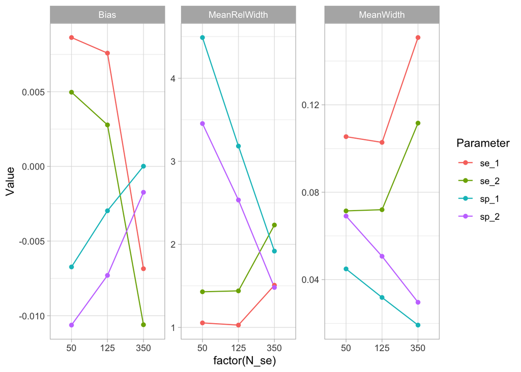

```r
sumres |>
  pivot_longer(c(Bias,MeanWidth,MeanRelWidth), names_to="Summary", values_to="Value") |>
  ggplot(aes(x=factor(N_se), y=Value, col=Parameter, group=Parameter)) +
  geom_line() +
  geom_point() +
  facet_wrap(~Summary, scales="free_y")
```

The biases are fairly small so I don’t think we should use that to optimise. As expected, there is a tradeoff between estimating se and sp in terms of number of samples from Sweden.

One way to simplify the tradeoff is just to average over the 4 parameters:

```r
sumres |>
  group_by(Scenario, N_se) |>
  summarise(AvgMeanWidth = mean(MeanWidth), AvgMeanRelWidth = mean(MeanRelWidth), .groups="drop") ->
  aggres
aggres
```

```
## # A tibble: 3 × 4
##   Scenario  N_se AvgMeanWidth AvgMeanRelWidth
##      <int> <dbl>        <dbl>           <dbl>
## 1        1   350       0.0778            1.79
## 2        2   125       0.0643            2.05
## 3        3    50       0.0727            2.61
```

Shown in a plot:

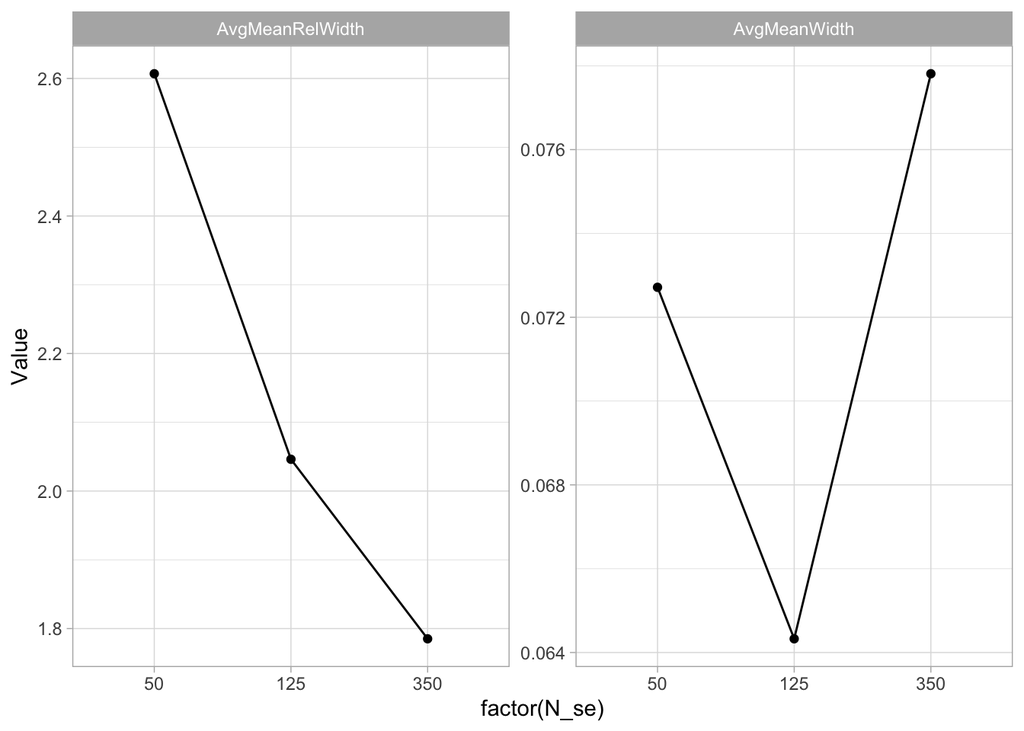

```r
aggres |>
  pivot_longer(c(AvgMeanWidth,AvgMeanRelWidth), names_to="Summary", values_to="Value") |>
  ggplot(aes(x=factor(N_se), y=Value, group=Summary)) +
  geom_line() +
  geom_point() +
  facet_wrap(~Summary, scales="free_y")
```

My feeling is that the relative width ignores the sensitivity too much, so we should be looking at the average mean width instead. But I am not 100% sure about this!

### Finding an optimum

Once we are settled on the average mean width of 95% CI as an objective function then we can begin the optimisation process. Let’s assume that we are happy with the average mean width for now and look at how to optimise that.

There are a number of potential strategies, but we have two limitations:

1. The objective function is a Monte Carlo approximation, and this numerical instability will play havoc with automated solvers
2. It is somewhat computationally intensive, so we should be economical with our strategy

Initially I was playing around with standard global optimisation strategies, but these didn’t work too well fo the above reasons. So now I prefer the following strategy:

1. Optimise for the proportion of samples going to the lowest prevalence country (Sweden), over the range 50-350 samples in e.g. blocks of 10, with the rest of the samples split evenly between the remaining 3 countries (ensuring that the total is always 500 by increasing allocation to Sweden after flooring the split, where necessary). Once the optimum is found for Sweden, fix it.
2. Optimise for the proportion of the remaining samples going to the highest prevalence country, with a minimum of samples and maximum allowing at least 50 samples each for the remaining 2 countries, with the rest of the samples split evenly between the remaining 2 countries. Once the optimum is found, fix it for this country as well.
3. Optimise for the proportion of the remaining samples being split between the two middle-prevalence countries, with a minumum and maximum of 50 each.

The potential criticism is that we are not guaranteed to find the global optimum, but I think we will at least find something close…

So the overall summarisation/objective function would be:

```r
objfun <- function(x){
  # if(any(is.na(x))) browser()
  stopifnot(!is.na(x$LCI), !is.na(x$UCI), x$PSRF < 1.1, x$SSeff >= 400L)
  x |>
    mutate(Width = UCI-LCI) |>
    group_by(Scenario, N_uk, N_nl, N_fr, N_se, Parameter) |>
    summarise(MeanWidth = mean(Width), MeanRelWidth = MeanWidth/(1-mean(Target)), .groups="drop_last") |>
    summarise(AvgMeanWidth = mean(MeanWidth), AvgMeanRelWidth = mean(MeanRelWidth), .groups="drop")
}
```

And a complete pipeline for running the first part of the optimisation would be:

```r
tibble(N_se = seq(50,350,by=10)) |>
  mutate(N_left = 500 - N_se) |>
  mutate(N_uk = floor(N_left/3), N_nl = floor(N_left/3), N_fr = floor(N_left/3)) |>
  mutate(N_se = 500-(N_uk+N_nl+N_fr)) |>
  mutate(Scenario = row_number()) |>
  cross_join(
    tibble(prev_uk=0.5, prev_nl=0.4, prev_fr=0.7, prev_se=0, se_1=0.7, sp_1=0.99, se_2=0.9, sp_2=0.98)
  ) |>
  group_split(Scenario) |>
  lapply(datafun, iterations=50) |>
  flatten() |>
  modelfun(cl=10L, sweden_prior="dbeta(1,1)") |>
  objfun() ->
  results_1
```

[Takes around 2 mins on my machine]

Where results look like:

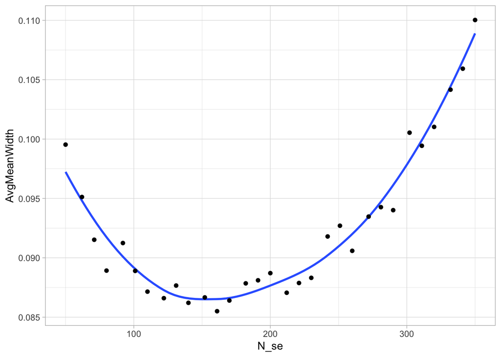

```r
results_1 |>
  ggplot(aes(x=N_se, y=AvgMeanWidth)) +
  geom_smooth(se=FALSE, method="loess", formula=y~x) +
  geom_point()
```

Note the numerical instability: we can counter this by increasing from 50 to e.g. 250 datasets per scenario (perhaps as a second sub-step in the area that “looks good” based on this coarser look).

Another note is that you can change the prior for Sweden, but this seems to make very little difference to the se/sp estimates (although it does to the prevalence estimate for Sweden).

### Wrapping into a function

To automate this process, we need to wrap it inside a function that finds/returns the optimum from within a given search space:

```r
opti_size <- function(N_search, N_tot, N_prop, parameters, iterations, ...){

  ## N_tot should be a single integer:
  stopifnot(is.numeric(N_tot), length(N_tot)==1L, !is.na(N_tot), N_tot%%1==0L)

  ## N_prop should be a named numeric vector of length 4, and exactly 1 missing:
  stopifnot(is.numeric(N_prop), length(N_prop)==4L, sum(is.na(N_prop))==1, !is.null(names(N_prop)), c("uk","nl","fr","se")%in%names(N_prop))
  N_prop <- N_prop / sum(N_prop, na.rm=TRUE)

  ## Should be a vector of candidate N for country:
  stopifnot(is.numeric(N_search))
  N_search <- sort(unique(N_search))

  ## Should be a data frame with 1 row:
  stopifnot(is.data.frame(parameters), nrow(parameters)==1L, all(c("prev_uk", "prev_nl", "prev_fr", "prev_se", "se_1", "sp_1", "se_2", "sp_2") %in% names(parameters)))

  Nsrch <- str_c("N_", names(N_prop)[is.na(N_prop)])

  ## Convert search space into total N and cross join with parameters:
  tibble(Country = names(N_prop), Proportion = N_prop) |>
    filter(!is.na(Proportion)) |>
    expand_grid(
      tibble(N_search = N_search, N_left = N_tot - N_search) |>
        rowid_to_column("Scenario")
    ) |>
    mutate(N = floor(Proportion * N_left)) |>
    group_by(Scenario) |>
    mutate(N_search = N_tot - sum(N)) |>
    ungroup() |>
    select(Country, Scenario, N_search, N) |>
    mutate(Country = str_c("N_", Country)) |>
    pivot_wider(names_from = Country, values_from = N) |>
    rename_with(function(x) ifelse(x=="N_search", Nsrch, x)) |>
    cross_join(parameters |> select(starts_with(c("prev", "se", "sp")))) ->
    search_parameters

  ## Run simulations:
  search_parameters |>
    group_split(Scenario) |>
    lapply(datafun, iterations=iterations) |>
    flatten() |>
    modelfun(...) |>
    objfun() ->
    results

  ## Use a polynomial approximation to find the optimum (not using):
  if(FALSE){
    poly_degree <- 3L
    pp <- poly(results[[Nsrch]], degree=poly_degree)
    coefs <- attr(pp, "coefs")
    fit <- lm(results[["AvgMeanWidth"]] ~ pp)
    predfun <- function(x) predict(fit, newdata = list(pp=poly(x, length(coefs[["alpha"]]), coefs=coefs)))
    N_opt <- optimise(predfun, range(N_search))[["minimum"]]
  }

  ## Use loess to find an optimum (using):
  results[["N"]] <- results[[Nsrch]]
  fit <- loess(AvgMeanWidth ~ N, data=results)
  predfun <- function(x) predict(fit, data.frame(N=x))
  ssrch <- seq(min(N_search), max(N_search), by=1)
  ssrch <- ssrch[sample.int(length(ssrch))]
  N_opt <- ssrch[which.min(predfun(ssrch))]

  N_prop <- floor(N_prop*(N_tot-N_opt))
  N_prop[is.na(N_prop)] <- N_tot - sum(N_prop, na.rm=TRUE)
  stopifnot(sum(N_prop)==N_tot)

  ## Make a data frame of the smoothed approximation:
  tibble(N = seq(min(N_search), max(N_search), by=1)) |>
    mutate(Approx = predfun(N)) |>
    full_join(
      results |> select(N = {{ Nsrch }}, Obs = AvgMeanWidth),
      by="N"
    ) ->
    smoothed

  # ggplot(smoothed) + geom_line(aes(x=N, y=Approx)) + geom_point(aes(x=N, y=Obs))

  ## And return:
  return(list(optimum = N_prop, results = results, smoothed = smoothed))
}
```

### Rotating between countries:

And then we need another function a level higher that rotates between countries within a given search space:

```r
rotate_countries <- function(prop_bounds, N_tot, parameters, iterations=50L, resolution=25L, repeats=5L, plot=TRUE, plot_file="", ...){

  ## prop_bounds should be a data frame with 4 rows:
  stopifnot(is.data.frame(prop_bounds), nrow(prop_bounds)==4L, c("Country", "Lower", "Upper") %in% names(prop_bounds), c("uk", "nl", "fr", "se") %in% prop_bounds[["Country"]])

  N_prop <- rep(1,4L)
  names(N_prop) <- prop_bounds[["Country"]]

  allres <- vector('list', length=repeats)
  for(r in 1:repeats){
    cat("Repeat ", r, " of ", repeats, "...\n", sep="")

    intres <- vector('list', length=4L)
    for(c in 1:4){
      cat("Country ", c, " of 4...\n", sep="")
      N_prop[c] <- NA_real_

      N_search <- seq(prop_bounds[["Lower"]][c], prop_bounds[["Upper"]][c], length.out=resolution)
      rr <- opti_size(N_search = N_search, N_tot = N_tot, N_prop = N_prop, parameters = parameters, iterations = iterations, ...)

      N_prop <- rr[["optimum"]]
      stopifnot(abs(sum(N_prop)-N_tot) <= sqrt(.Machine$double.eps))

      intres[[c]] <- rr[["smoothed"]] |> mutate(Country = names(N_prop)[c], Repeat = r)
    }
    allres[[r]] <- intres |> bind_rows()

    if(plot || r==repeats){
      smoothed <- allres |> bind_rows()
      pt <- ggplot(smoothed, aes(x=N, y=Approx, col=Repeat, group=Repeat)) +
        geom_line() +
        facet_wrap(~Country)
      if(plot){
        if(plot_file=="") print(pt) else ggsave(plot_file, pt)
      }
    }
  }

  return(list(optimum = N_prop, smoothed = smoothed, plot = pt))
}
```

Save the functions for use externally:

```r
save(datafun, modelfun, objfun, opti_size, rotate_countries, file="functions.rda")
```

These can (temporarily) be downloaded from: (https://www.costmodds.org/projects/covetlabLCM/functions.rda)[https://www.costmodds.org/projects/covetlabLCM/functions.rda]